# MAT3373: Long Homework #2

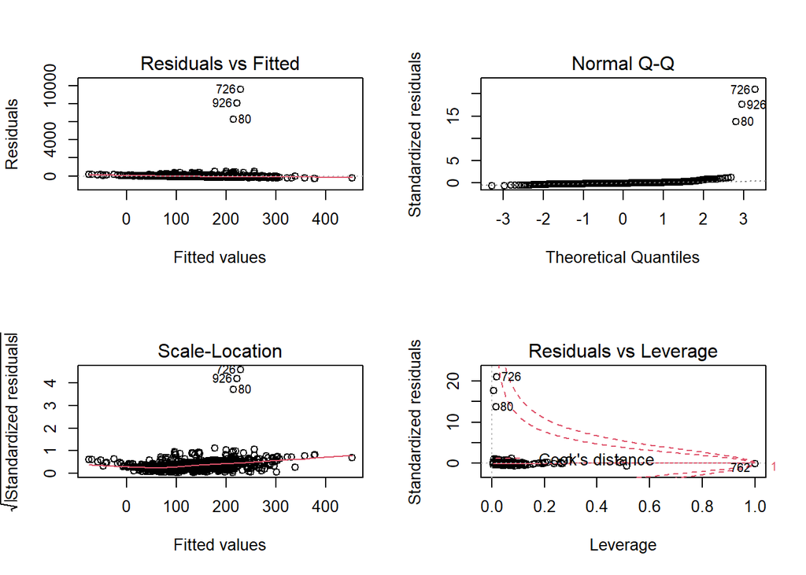

```r
#attach(L_data_clean)

par(mfrow=c(2,2))
plot(fit_lm)
```

**Train using Linear Regression on L_data_clean_r (dataset with points removed.)**

```r
fit_lm_r = lm(price~., data = L_data_clean_r)

predictions_lm_r = predict(fit_lm_r, data = L_data_clean_test)
predictions_lm_r[1:10]
```

```
##         1         2         3         4         5         6         7         8
##  93.19005 101.77661 182.13087 192.33900  74.02516  90.78777 147.89633 141.41436
##         9        10
##  12.47224  87.34691
```

```r
RMSE(predictions_lm_r, L_data_clean_test$price)
```

```
## [1] 90.53268
```

```r
summary(fit_lm_r)
```

```
##
## Call:
## lm(formula = price ~ ., data = L_data_clean_r)
##
## Residuals:
##     Min      1Q  Median      3Q     Max
## -200.48  -39.07  -12.30   18.15  587.05
##
## Coefficients:
##                                                Estimate Std. Error t value
## (Intercept)                                  -6.534e+03  3.502e+03  -1.866
## host_response_rate                            1.937e+01  1.561e+01   1.241
## host_acceptance_rate                         -6.069e-01  1.071e+01  -0.057
## host_is_superhost                             1.218e+00  5.853e+00   0.208
## host_listings_count                          -6.294e-02  2.232e-01  -0.282
## host_has_profile_pic                         -2.958e+01  4.029e+01  -0.734
## host_identity_verified                        1.128e+01  6.764e+00   1.667
## latitude                                      6.455e+01  4.880e+01   1.323
## longitude                                    -4.644e+01  2.636e+01  -1.761
## accommodates                                  8.417e+00  2.259e+00   3.725
## bedrooms                                      3.090e+01  4.847e+00   6.375
## beds                                         -6.041e+00  3.435e+00  -1.759
## minimum_nights                                1.393e-01  8.014e-02   1.738
## maximum_nights                               -4.661e-08  3.731e-08  -1.249
## has_availability                              3.706e+01  1.665e+01   2.226
## number_of_reviews                            -2.576e-01  7.857e-02  -3.279
## number_of_reviews_ltm                        -2.635e-01  3.573e-01  -0.737
## number_of_reviews_l30d                       -1.618e+00  4.687e+00  -0.345
## review_scores_rating                          1.379e+00  9.172e-01   1.504
## review_scores_accuracy                       -1.487e+00  6.221e+00  -0.239
## review_scores_cleanliness                     1.879e+00  5.642e+00   0.333
## review_scores_checkin                        -9.981e-01  8.359e+00  -0.119
## review_scores_communication                   1.516e+00  9.187e+00   0.165
## review_scores_location                        1.809e+01  4.906e+00   3.688
## review_scores_value                          -1.948e+01  5.630e+00  -3.460
## instant_bookable                             -7.922e+00  6.417e+00  -1.235
## calculated_host_listings_count               -3.280e+01  1.633e+01  -2.009
## calculated_host_listings_count_entire_homes   3.310e+01  1.633e+01   2.028
## calculated_host_listings_count_private_rooms  2.660e+01  1.644e+01   1.618
## reviews_per_month                             6.826e+00  4.551e+00   1.500
```

[output cut: 22 more lines]

```
## review_scores_checkin                        0.904980
## review_scores_communication                  0.868945
## review_scores_location                       0.000238 ***
## review_scores_value                          0.000563 ***
## instant_bookable                             0.217286
## calculated_host_listings_count               0.044859 *
## calculated_host_listings_count_entire_homes  0.042878 *
## calculated_host_listings_count_private_rooms 0.106040
## reviews_per_month                            0.133992
## ---
## Signif. codes:  0 '***' 0.001 '**' 0.01 '*' 0.05 '.' 0.1 ' ' 1
##
## Residual standard error: 78.2 on 970 degrees of freedom
## Multiple R-squared:  0.3142, Adjusted R-squared:  0.2937
## F-statistic: 15.33 on 29 and 970 DF,  p-value: < 2.2e-16
```

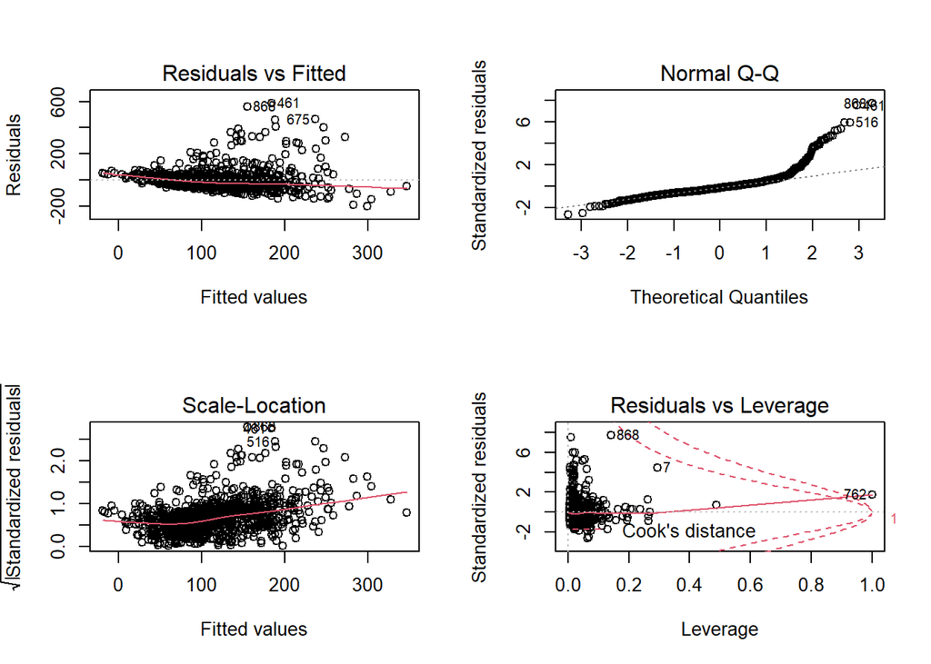

```r
par(mfrow=c(2,2))
plot(fit_lm_r)
```

**(3) Which of the models in the previous question is best? Was it OK to remove the suspicious datapoints from the training dataset? Were the error estimates from the optimization dataset accurate?**

The best model, based on $RMSE = 64.2$, is the LASSO model fit on the data set with outliers removed, with Lambda chosen based on cross-validated errors on the optimized data set. The second best performing model is the linear regression fit on the data set with outliers removed, with $RMSE = 90.5$.

Based on the lower error on both models using the modified data set, as well as the linear coefficients having statistically significant values once the extreme outliers were removed, it was OK to remove them. The outliers skewed the regression line and produced a model with $Adjusted R^2 = -0.009605$, implying the variables do not have any association with the dependent variable (price). The model without these points has $Adjusted R^2 = 0.2937$, which indicates there is some relationship between the variables and price.

No, the optimization dataset did not accurately estimate the model errors. Looking at the CV plots, the error estimates are very close for both fits, yet their actual test errors are quite different (159.9 compared to 64.2).

**(4) Some of the features, such as “description” and “amenities,” are text fields or text lists. Choose a collection of words** $W$ **that appear somewhere in these variables. For each word** $w ∈ W$**, create a** ${0, 1}$**-valued dummy variable that indicates the presence of a given word in a given listing’s text field. For a word w, denote by** $p(w)$ **the percentage of listings containing that word. Denote by n the number of listings in the training set. Ensure that your collection of words** $W$ **satisfies:**

**(a)** $\sum_w ∈ W p(w) ≥ \frac{n}{2}$

**(b)** $|W| ≥ 12$ **(that is, there are many words in the collection).**

**(c) Very common words such as “the” or “and” should not appear in the collection.**

```r
library(stringr)

desc <- L_data_clean_r_all$description
amen <- L_data_clean_r_all$amenities
amen[1:3]
```

```
## [1] "[\"Essentials\", \"TV\", \"Hair dryer\", \"Washer\", \"Dryer\", \"Wifi\", \"Heating\", \"Iron\", \"Free parking on premises\", \"First aid kit\", \"Long term stays allowed\", \"Hot water\", \"Hangers\", \"Elevator\", \"Smoke alarm\", \"Air conditioning\", \"Kitchen\", \"Carbon monoxide alarm…
## [2] "[\"Coffee maker\", \"Hair dryer\", \"Cable TV\", \"Wifi\", \"Breakfast\", \"Microwave\", \"Bed linens\", \"Extra pillows and blankets\", \"Refrigerator\", \"Iron\", \"Free parking on premises\", \"First aid kit\", \"Hot water\", \"Hangers\", \"Cooking basics\", \"Luggage dropoff allowed\", \…
## [3] "[\"Coffee maker\", \"Window guards\", \"Hair dryer\", \"Cable TV\", \"Wifi\", \"Microwave\", \"Bed linens\", \"Extra pillows and blankets\", \"Shower gel\", \"Garden or backyard\", \"Refrigerator\", \"Iron\", \"Free parking on premises\", \"First aid kit\", \"Hot water\", \"Hangers\", \"Cook…
```

```r
clean <- function(string){
    temp <- tolower(string)
    temp <- stringr::str_replace_all(temp,"[^a-zA-Z\\s]", " ")
    temp <- stringr::str_replace_all(temp,"[\\s]+", " ")
    temp <- stringr::str_split(temp, " ")[[1]]
    indexes <- which(temp == "")
    if(length(indexes) > 0){
      temp <- temp[-indexes]
    }
    return(temp)
}

# concatenate first 12 posts

d <- paste(desc[1], desc[2], desc[3], desc[4], desc[5], desc[6], desc[7], desc[8], desc[9], desc[10], desc[11], desc[12])
s <- paste(amen[1], amen[2], amen[3], amen[4], amen[5], amen[6], amen[7], amen[8], amen[9], amen[10], amen[11], amen[12])

clean_s <- clean(s)

# remove words length < 4

for(i in 1:length(clean_s)){
  if(nchar(clean_s[i]) < 4){
    clean_s[i] <- NA
  }
}

clean_s <- clean_s[-which(is.na(clean_s))]

# get unique words

clean_u <- unique(clean_s)
clean_u
```

```
##   [1] "essentials"   "hair"         "dryer"        "washer"       "wifi"
##   [6] "heating"      "iron"         "free"         "parking"      "premises"
##  [11] "first"        "long"         "term"         "stays"        "allowed"
##  [16] "water"        "hangers"      "elevator"     "smoke"        "alarm"
##  [21] "conditioning" "kitchen"      "carbon"       "monoxide"     "coffee"
##  [26] "maker"        "cable"        "breakfast"    "microwave"    "linens"
##  [31] "extra"        "pillows"      "blankets"     "refrigerator" "cooking"
##  [36] "basics"       "luggage"      "dropoff"      "fire"         "extinguisher"
##  [41] "host"         "greets"       "private"      "entrance"     "patio"
##  [46] "balcony"      "dedicated"    "workspace"    "shampoo"      "dishes"
##  [51] "silverware"   "stove"        "oven"         "dishwasher"   "window"
##  [56] "guards"       "shower"       "garden"       "backyard"     "building"
##  [61] "staff"        "paid"         "baking"       "sheet"        "cleaning"
##  [66] "before"       "checkout"     "pocket"       "room"         "darkening"
##  [71] "shades"       "crib"         "grill"        "ethernet"     "connection"
##  [76] "single"       "level"        "home"         "bathtub"      "smart"
##  [81] "lock"         "baby"         "safety"       "gates"        "bedroom"
##  [86] "door"         "driveway"     "space"        "conditioner"  "keypad"
##  [91] "body"         "soap"         "unit"         "central"      "portable"
##  [96] "fans"         "hdtv"         "pour"         "over"         "barbecue"
## [101] "utensils"     "indoor"       "fireplace"    "kettle"       "heater"
## [106] "wine"         "glasses"      "clothing"     "storage"      "closet"
## [111] "dresser"      "toaster"      "freezer"      "desk"         "dining"
## [116] "table"        "products"     "lake"         "access"       "dove"
```

```r
n_col <- length(clean_u) + 1

# create frequency matrix and load amenitites data

m <- matrix(nrow=1002,ncol=n_col)
m[2:1001,1] <- amen
m[1,2:n_col] <- clean_u

# count frequency for each word and post

for(j in 2:1001){
  for(i in 2:n_col){
    m[j,i] <- sum(grepl(m[1,i], m[j,1]))
  }
}
for(i in 2:n_col){

  m[1002,i] <- length(m[,i][which(m[,i] == "1")])
}

# view total frequencies of words

view <- matrix(nrow = 2, ncol = n_col)
view[1,] <- m[1,]
view[2,] <- m[1002,]
view
```

```
##      [,1] [,2]         [,3]   [,4]    [,5]     [,6]   [,7]      [,8]   [,9]
## [1,] NA   "essentials" "hair" "dryer" "washer" "wifi" "heating" "iron" "free"
## [2,] NA   "23"         "94"   "780"   "380"    "29"   "5"       "0"    "0"
##      [,10]     [,11]      [,12]   [,13]  [,14]  [,15]   [,16]     [,17]
## [1,] "parking" "premises" "first" "long" "term" "stays" "allowed" "water"
## [2,] "902"     "817"      "0"     "0"    "812"  "812"   "864"     "764"
##      [,18]     [,19]      [,20]   [,21]   [,22]          [,23]     [,24]
## [1,] "hangers" "elevator" "smoke" "alarm" "conditioning" "kitchen" "carbon"
## [2,] "0"       "0"        "0"     "966"   "812"          "6"       "0"
##      [,25]      [,26]    [,27]   [,28]   [,29]       [,30]       [,31]
## [1,] "monoxide" "coffee" "maker" "cable" "breakfast" "microwave" "linens"
## [2,] "840"      "23"     "605"   "2"     "0"         "0"         "537"
##      [,32]   [,33]     [,34]      [,35]          [,36]     [,37]    [,38]
## [1,] "extra" "pillows" "blankets" "refrigerator" "cooking" "basics" "luggage"
## [2,] "0"     "445"     "445"      "2"            "0"       "583"    "0"
##      [,39]     [,40]  [,41]          [,42]  [,43]    [,44]     [,45]
## [1,] "dropoff" "fire" "extinguisher" "host" "greets" "private" "entrance"
## [2,] "311"     "280"  "655"          "0"    "157"    "0"       "385"
##      [,46]   [,47]     [,48]       [,49]       [,50]     [,51]    [,52]
## [1,] "patio" "balcony" "dedicated" "workspace" "shampoo" "dishes" "silverware"
## [2,] "0"     "387"     "0"         "785"       "1"       "0"      "649"
##      [,53]   [,54]  [,55]        [,56]    [,57]    [,58]    [,59]    [,60]
## [1,] "stove" "oven" "dishwasher" "window" "guards" "shower" "garden" "backyard"
## [2,] "12"    "8"    "0"          "0"      "34"     "0"      "1"      "350"
##      [,61]      [,62]   [,63]  [,64]    [,65]   [,66]      [,67]    [,68]
## [1,] "building" "staff" "paid" "baking" "sheet" "cleaning" "before" "checkout"
## [2,] "3"        "21"    "0"    "0"      "74"    "0"        "62"     "62"
##      [,69]    [,70]  [,71]       [,72]    [,73]  [,74]   [,75]
## [1,] "pocket" "room" "darkening" "shades" "crib" "grill" "ethernet"
## [2,] "0"      "194"  "128"       "128"    "86"   "198"   "0"
##      [,76]        [,77]    [,78]   [,79]  [,80]     [,81]   [,82]  [,83]
## [1,] "connection" "single" "level" "home" "bathtub" "smart" "lock" "baby"
## [2,] "70"         "0"      "65"    "65"   "0"       "0"     "48"   "0"
##      [,84]    [,85]   [,86]     [,87]  [,88]      [,89]   [,90]
## [1,] "safety" "gates" "bedroom" "door" "driveway" "space" "conditioner"
## [2,] "37"     "37"    "180"     "409"  "7"        "786"   "2"
##      [,91]    [,92]  [,93]  [,94]  [,95]     [,96]      [,97]  [,98]  [,99]
## [1,] "keypad" "body" "soap" "unit" "central" "portable" "fans" "hdtv" "pour"
## [2,] "0"      "4"    "24"   "10"   "0"       "0"        "25"   "0"    "0"
##      [,100] [,101]     [,102]     [,103]   [,104]      [,105]   [,106]   [,107]
## [1,] "over" "barbecue" "utensils" "indoor" "fireplace" "kettle" "heater" "wine"
## [2,] "40"   "0"        "37"       "0"      "280"       "18"     "1"      "0"
##      [,108]    [,109]     [,110]    [,111]   [,112]    [,113]    [,114]
## [1,] "glasses" "clothing" "storage" "closet" "dresser" "toaster" "freezer"
## [2,] "15"      "7"        "11"      "5"      "4"       "0"       "0"
##      [,115] [,116]   [,117]  [,118]     [,119] [,120]   [,121]
## [1,] "desk" "dining" "table" "products" "lake" "access" "dove"
## [2,] "3"    "8"      "44"    "17"       "0"    "20"     "0"
```

```r
# pick top words >500

view[, c(4,10,11,14,16,21,22,25,31,41,49,52,89)]
```

```
##      [,1]    [,2]      [,3]       [,4]   [,5]      [,6]    [,7]
## [1,] "dryer" "parking" "premises" "term" "allowed" "alarm" "conditioning"
## [2,] "780"   "902"     "817"      "812"  "864"     "966"   "812"
##      [,8]       [,9]     [,10]          [,11]       [,12]        [,13]
## [1,] "monoxide" "linens" "extinguisher" "workspace" "silverware" "space"
## [2,] "840"      "537"    "655"          "785"       "649"        "786"
```

```r
# create dummy variables in original file

L_data_clean_r_all[m[1,c(4,10,11,14,16,21,22,25,31,41,49,52,89)]] <- m[2:1001, c(4,10,11,14,16,21,22,25,31,41,49,52,89)]
L_data_clean_r_all = subset(L_data_clean_r_all, select = -c(description, neighborhood_overview, host_response_time, neighbourhood_cleansed, property_type, room_type, amenities, first_review, last_review))
L_data_clean_r_all[1:5,]
```

```
##   host_response_rate host_acceptance_rate host_is_superhost host_listings_count
## 1          1.0000000            0.9400000                 1                   5
## 2          1.0000000            0.5000000                 0                   4
## 3          1.0000000            0.9200000                 0                   3
## 4          1.0000000            1.0000000                 1                   1
## 5          0.9245455            0.7686585                 1                   0
##   host_has_profile_pic host_identity_verified latitude longitude accommodates
## 1                    0                      0 45.43155 -75.56861            4
## 2                    0                      0 45.43479 -75.68787            2
## 3                    0                      0 45.42986 -75.69486            7
## 4                    0                      0 45.22002 -75.67427            8
## 5                    0                      0 45.35638 -75.76115            3
##   bedrooms beds price minimum_nights maximum_nights has_availability
## 1        1    2   109              5           1125                0
## 2        1    1    96              5            365                0
```

[output cut: 51 more lines]

**(5) Repeat model-training for both standard and LASSO regression on this larger collection of covariates (with outliers removed or not per the results of the previous part of the question). How do the results change?**

```r
# add dummy variables to test set

amen_t <- L_data_clean_test_all$amenities

# create frequency matrix and load amenitites data from test set

m_t <- matrix(nrow=673,ncol=n_col)
m_t[2:672,1] <- amen_t
m_t[1,2:n_col] <- clean_u

# count frequency for each word and post

for(j in 2:672){
  for(i in 2:n_col){
    m_t[j,i] <- sum(grepl(m_t[1,i], m_t[j,1]))
  }
}

# add dummy variables to original set

L_data_clean_test_all[m_t[1,c(4,10,11,14,16,21,22,25,31,41,49,52,89)]] <- m_t[2:672, c(4,10,11,14,16,21,22,25,31,41,49,52,89)]
L_data_clean_test_all = subset(L_data_clean_test_all, select = -c(description, neighborhood_overview, host_response_time, neighbourhood_cleansed, property_type, room_type, amenities, first_review, last_review))
L_data_clean_test_all[1:5,]
```

```
##   host_response_rate host_acceptance_rate host_is_superhost host_listings_count
## 1          0.9433684                 0.00                 1                   1
## 2          0.6700000                 0.69                 1                   0
## 3          0.9433684                 1.00                 1                   0
## 4          0.9433684                 0.93                 0                   0
## 5          0.8000000                 1.00                 1                   4
##   host_has_profile_pic host_identity_verified latitude longitude accommodates
## 1                    0                      1 45.44238 -75.66747            1
## 2                    0                      0 45.44711 -75.46192            8
## 3                    0                      1 45.43658 -75.67580            4
## 4                    0                      0 45.40653 -75.70076            2
## 5                    0                      0 45.35344 -75.72580            2
##   bedrooms beds price minimum_nights maximum_nights has_availability
## 1        1    1   100              2           1125                0
## 2        4    4   350              1           1125                0
```

[output cut: 51 more lines]

```r
# add dummy variables to opt set

amen_o <- L_data_clean_opt_all$amenities

# create frequency matrix and load amenitites data from opt set

m_o <- matrix(nrow=1002,ncol=n_col)
m_o[2:1001,1] <- amen_o
m_o[1,2:n_col] <- clean_u

# count frequency for each word and post

for(j in 2:1001){
  for(i in 2:n_col){
    m_o[j,i] <- sum(grepl(m_o[1,i], m_o[j,1]))
  }
}

# add dummy variables to original set

L_data_clean_opt_all[m_o[1,c(4,10,11,14,16,21,22,25,31,41,49,52,89)]] <- m_o[2:1001, c(4,10,11,14,16,21,22,25,31,41,49,52,89)]
L_data_clean_opt_all = subset(L_data_clean_opt_all, select = -c(description, neighborhood_overview, host_response_time, neighbourhood_cleansed, property_type, room_type, amenities, first_review, last_review))
L_data_clean_opt_all[1:5,]
```

```
##   host_response_rate host_acceptance_rate host_is_superhost host_listings_count
## 1        0.010000000                 0.98                 1                   3
## 2        0.010000000                 0.95                 0                   2
## 3        0.010000000                 1.00                 1                   3
## 4        0.010000000                 0.98                 0                   1
## 5        0.009245455                 0.95                 1                   3
##   host_has_profile_pic host_identity_verified latitude longitude accommodates
## 1                    0                      0 45.27686 -75.84281            2
## 2                    0                      0 45.28117 -75.85297            4
## 3                    0                      0 45.36225 -75.71099            2
## 4                    0                      0 45.42407 -75.66118            4
## 5                    0                      0 45.35184 -75.70845            1
##   bedrooms beds price minimum_nights maximum_nights has_availability
## 1        1    1    38              2           1125                0
## 2        1    2    80              3            120                0
```

[output cut: 51 more lines]

**Train using LASSO and CV on L_data_clean_r_all (dataset with outlier points removed and all dummy variables included.)**

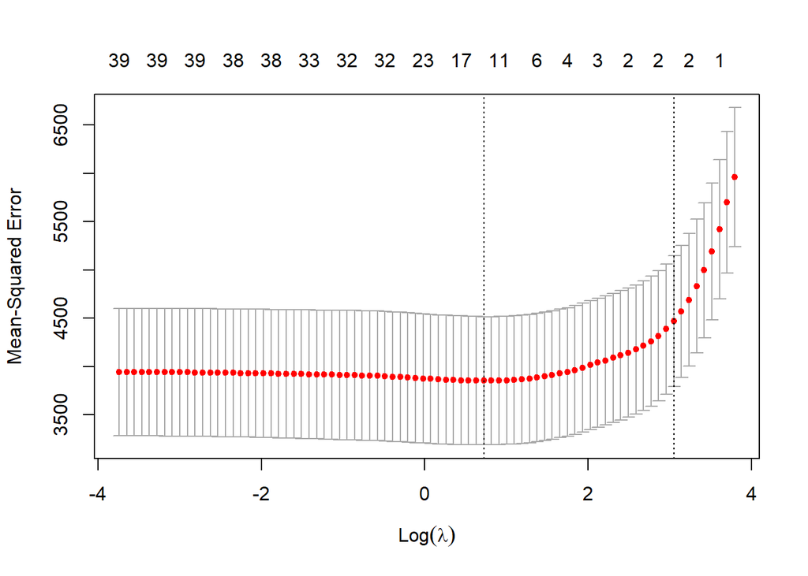

```r
# fit Lasso with CV model (modified set including dummy variables)

x_r2 = model.matrix(price~.,data=L_data_clean_r_all)
y_r2 = L_data_clean_r_all$price

x_opt_r2 = model.matrix(price~.,data=L_data_clean_opt_all)
y_opt_r2 = L_data_clean_opt_all$price

fit_lasso_r2 = glmnet(x_r2, y_r2, alpha = 1)

cv_lasso_r2 = cv.glmnet(x_opt_r2, y_opt_r2, alpha = 1)

plot(cv_lasso_r2)
```

```r
min_r2 <- cv_lasso_r2$lambda.min

coef(cv_lasso_r2, s = "lambda.min")
```

```
## 44 x 1 sparse Matrix of class "dgCMatrix"
##                                                          1
## (Intercept)                                  -607.43002092
## (Intercept)                                     .
## host_response_rate                              .
## host_acceptance_rate                           11.76434981
## host_is_superhost                               .
## host_listings_count                             .
## host_has_profile_pic                            .
## host_identity_verified                          .
## latitude                                        .
## longitude                                      -8.46784245
## accommodates                                    6.47629937
## bedrooms                                       28.22072382
## beds                                            .
## minimum_nights                                  .
## maximum_nights                                  .
## has_availability                                .
## number_of_reviews                              -0.18326346
## number_of_reviews_ltm                          -0.05874019
## number_of_reviews_l30d                          .
## review_scores_rating                            .
## review_scores_accuracy                          .
## review_scores_cleanliness                       .
## review_scores_checkin                           .
## review_scores_communication                     .
## review_scores_location                          .
## review_scores_value                             .
## instant_bookable                               -0.58273226
## calculated_host_listings_count                  .
## calculated_host_listings_count_entire_homes     0.30406475
## calculated_host_listings_count_private_rooms   -3.87118008
## reviews_per_month                               .
## dryer1                                          .
## parking1                                       -3.26750708
## premises1                                       .
## term1                                           .
## allowed1                                       -2.71160554
## alarm1                                          .
## conditioning1                                   2.41775204
## monoxide1                                       .
## linens1                                         .
## extinguisher1                                   .
## workspace1                                      .
## silverware1                                     .
## space1                                          .
```

```r
lasso_predictions_r2 <- predict(fit_lasso_r2, newx = model.matrix(price~.,data=L_data_clean_test_all), s = min_r2)

RMSE(lasso_predictions_r2, L_data_clean_test$price)
```

```
## [1] 62.28037
```

**Train using Linear Regression on L_data_clean_r_all (dataset with outlier points removed and all dummy variables included.)**

```r
# fit linear model (modified set including dummy variables)

fit_lm_r2 = lm(price~., data = L_data_clean_r_all)

predictions_lm_r2 = predict(fit_lm_r2, data = L_data_clean_test_all)

RMSE(predictions_lm_r2, L_data_clean_test_all$price)
```

```
## [1] 92.57209
```

```r
summary(fit_lm_r2)
```

```
##
## Call:
## lm(formula = price ~ ., data = L_data_clean_r_all)
##
## Residuals:
##     Min      1Q  Median      3Q     Max
## -183.31  -37.61   -9.80   20.59  569.73
##
## Coefficients:
##                                                Estimate Std. Error t value
## (Intercept)                                  -6.177e+03  3.498e+03  -1.766
## host_response_rate                            2.337e+01  1.551e+01   1.507
## host_acceptance_rate                          9.070e+00  1.068e+01   0.849
## host_is_superhost                            -3.360e+00  5.896e+00  -0.570
## host_listings_count                          -9.271e-02  2.203e-01  -0.421
## host_has_profile_pic                         -3.897e+01  3.997e+01  -0.975
## host_identity_verified                        5.627e+00  6.741e+00   0.835
## latitude                                      5.550e+01  4.876e+01   1.138
## longitude                                    -4.753e+01  2.612e+01  -1.819
## accommodates                                  9.253e+00  2.242e+00   4.127
## bedrooms                                      2.995e+01  4.796e+00   6.246
## beds                                         -6.160e+00  3.374e+00  -1.826
## minimum_nights                                1.595e-01  7.982e-02   1.998
## maximum_nights                               -5.273e-08  3.673e-08  -1.435
## has_availability                              2.849e+01  1.657e+01   1.719
## number_of_reviews                            -1.965e-01  7.844e-02  -2.505
## number_of_reviews_ltm                        -9.040e-02  3.526e-01  -0.256
## number_of_reviews_l30d                       -2.762e+00  4.630e+00  -0.596
## review_scores_rating                          9.596e-01  9.093e-01   1.055
## review_scores_accuracy                       -3.292e+00  6.129e+00  -0.537
## review_scores_cleanliness                     3.463e+00  5.596e+00   0.619
## review_scores_checkin                        -9.660e-01  8.265e+00  -0.117
## review_scores_communication                   3.148e+00  9.139e+00   0.344
## review_scores_location                        1.794e+01  4.883e+00   3.675
## review_scores_value                          -1.599e+01  5.583e+00  -2.864
## instant_bookable                             -4.795e+00  6.355e+00  -0.755
## calculated_host_listings_count               -3.372e+01  1.617e+01  -2.085
## calculated_host_listings_count_entire_homes   3.439e+01  1.617e+01   2.127
## calculated_host_listings_count_private_rooms  2.726e+01  1.628e+01   1.675
## reviews_per_month                             4.210e+00  4.513e+00   0.933
```

[output cut: 48 more lines]

```
## allowed1                                     0.045670 *
## alarm1                                       0.815343
## conditioning1                                0.175674
## monoxide1                                    0.021088 *
## linens1                                      0.217263
## extinguisher1                                0.020330 *
## workspace1                                   0.820227
## silverware1                                  0.007440 **
## space1                                       0.815181
## ---
## Signif. codes:  0 '***' 0.001 '**' 0.01 '*' 0.05 '.' 0.1 ' ' 1
##
## Residual standard error: 76.58 on 957 degrees of freedom
## Multiple R-squared:  0.351,  Adjusted R-squared:  0.3226
## F-statistic: 12.33 on 42 and 957 DF,  p-value: < 2.2e-16
```

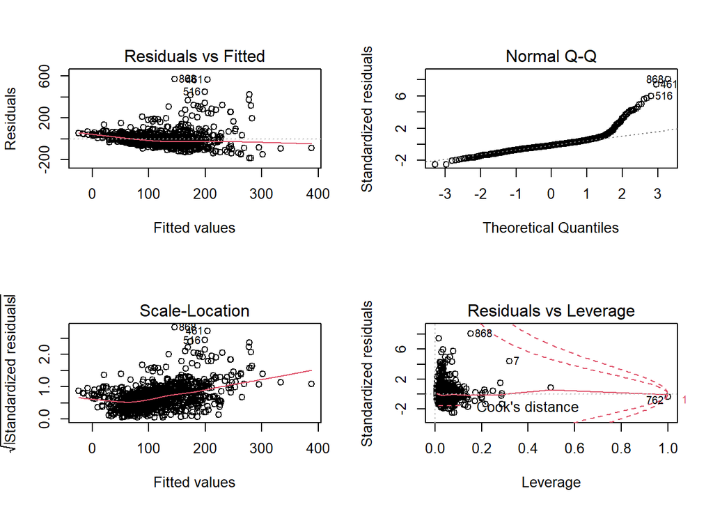

```r
par(mfrow=c(2,2))
plot(fit_lm_r2)
```

Surprisingly, the results are a little bit worse with linear regression despite several of the new variables having p-values $<0.05$. For linear regression, the error went from $90.5$ to $~92$. Looking at the coefficients for some of the variables, many of the amenitities are associated negatively with price, like ‘silverware’. It is statistically significant ($p-value = 0.007$), but seems to be associated with lower-priced units. Adding the dummy variables reduced the influence of ‘review_scores_value’ from $p = 0.00056$ to $0.004$. It is still significant, but perhaps some of the ‘value’ is reflective of the amenities.

For Lasso, the error decreased. It was $RMSE = 64$ before adding the amenities dummy variables, and after it is $62.3$. It gave significance to different amenities: parking (negative), ‘allowed’(negative), and conditioning (positive). There is not a lot of difference in predictive accuracy with the addition of the new variables.

### Question 8

**In this question, you will consider the “ridge” and “LASSO” penalties for the usual linear regression model:**

$$Y_i = β_0 + β_1X_i + \varepsilon_i$$

**(1) Show that, for any dataset** $(X_1, Y_1), . . . ,(X_n, Y_n)$**, there exists some finite value Λ so that for all choices of hyperparameter** $λ > Λ$**, the coefficients estimated by LASSO regression will all be exactly** $0$**.**

Referring to the textbook page 225, formulas 6.14 and 6.15 show a version of the Lasso and Ridge coefficient estimations under the following simplifying assumptions:

$n = p$,

$B_0 = 0$ (No intercept estimation),

and a simplified data matrix $X$ with 1’s along the diagonal and 0’s otherwise.

$β_j^R = y_j/(1 + λ)$

$β_j^L =$

$y_j − \frac{λ}{2}$ if $y_j > \frac{λ}{2}$

$y_j + \frac{λ}{2}$ if $y_j < -\frac{λ}{2}$

$0$ if $|y_j| ≤ \frac{λ}{2}$

Take some arbitrary data set $X$ with points $(X_1,Y_1),...,(X_n,Y_n)$, given the conditions above, and for any value $y_j \in X$ there exists a value $Λ = 2|y_j|$. This value $Λ$ is the minimum value for $β_j^L = 0$ according to the above identities, and so it holds that for any value $λ > Λ$, $β_j^L = 0$.

According to the authors of the textbook, this applies to data sets beyond these assumptions - i.e. including an intercept and additional coefficient parameters.

I will attempt to show this:

For a standard linear model

$$Y = β_0 + β_1X + \epsilon$$

Ridge minimizes RSS subject to a lambda penalty term:

$$\sum_{i=1}^{n} (Y_i - \hat{\beta}_0 - \hat{\beta}_1X_i)^2 + \lambda\hat{|\beta|}_1$$

Take partial derivative with respect to $β_0^R$:

$$\frac{\partial}{\partial \hat{\beta}_0} \sum_{i=1}^{n} (Y_i - \hat{\beta}_0 - \hat{\beta}_1X_i)^2 + \frac{\partial}{\partial \hat{\beta}_0} \lambda\hat{|\beta|}_1 = -2\sum_{i=1}^{n}(Y_i - \hat{\beta}_0 - \hat{\beta}_1X_i) +\lambda\hat{|\beta|}_1$$

Take partial derivative with respect to $β_1^R$:

$$\frac{\partial}{\partial \hat{\beta}_1} \sum_{i=1}^{n} (Y_i - \hat{\beta}_0 - \hat{\beta}_1X_i)^2 + \frac{\partial}{\partial \hat{\beta}_1} \lambda\hat{|\beta|}_1 = -2\sum_{i=1}^{n} X_i(Y_i - \hat{\beta}_0 - \hat{\beta}_1X_i) +\lambda\hat{\frac{\beta_1}{|\beta|}}_1$$

Set to 0:

$$-2\sum_{i=1}^{n}(Y_i - \hat{\beta}_0 - \hat{\beta}_1X_i) +\lambda\hat{|\beta|}_1 = 0$$

$$-2\sum_{i=1}^{n} X_i(Y_i - \hat{\beta}_0 - \hat{\beta}_1X_i) +\lambda\hat{\frac{\beta_1}{|\beta|}}_1 = 0$$

Divide by -2:

$$\sum_{i=1}^{n}(Y_i - \hat{\beta}_0 - \hat{\beta}_1X_i) -\frac{1}{2}\lambda\hat{|\beta_1|} = 0$$

$$\sum_{i=1}^{n} X_i(Y_i - \hat{\beta}_0 - \hat{\beta}_1X_i) -\frac{1}{2}\lambda\hat{\frac{\beta_1}{|\beta_1|}} = 0$$

Solving for $β_0^R$:

$\hat{\beta}_0^R = \bar{Y} - \hat{\beta_1}\bar{X} -\frac{1}{2n}\lambda\hat{|\beta|}_1$

Solving for $β_1^R$ (by substituting $β_0^R$ and distributing the summation):

$$\sum_{i=1}^{n} X_i(Y_i - (\bar{Y} - \hat{\beta_1}\bar{X} -\frac{1}{2n}\lambda\hat{|\beta_1|}) - \hat{\beta}_1X_i) -\frac{1}{2}\lambda\hat{\frac{\beta_1}{|\beta_1|}} = 0$$

$$\sum_{i=1}^{n} X_i(Y_i - \bar{Y} ) + \sum_{i=1}^{n} X_i\frac{1}{2n}\lambda\hat{|\beta_1|} - \sum_{i=1}^{n}\hat{\beta}_1 X_i (X_i - \bar{X}) -\frac{1}{2}\lambda\hat{\frac{\beta_1}{|\beta_1|}} = 0$$

$$\sum_{i=1}^{n} X_i(Y_i - \bar{Y} ) + \bar{X}\frac{1}{2}\lambda\hat{|\beta_1|} - \sum_{i=1}^{n}\hat{\beta}_1 X_i (X_i - \bar{X}) -\frac{1}{2}\lambda\hat{\frac{\beta}{|\beta_1|}} = 0$$

$$\sum_{i=1}^{n} X_i(Y_i - \bar{Y} ) - \sum_{i=1}^{n}\hat{\beta}_1 X_i (X_i - \bar{X}) - \lambda\frac{1}{2} (\bar{X}\hat{|\beta_1|} + \hat{\frac{\beta_1}{|\beta_1|}}) = 0$$

$$\hat{\beta}_1 \sum_{i=1}^{n} X_i (X_i - \bar{X}) - \lambda\frac{1}{2} (\bar{X}\hat{|\beta_1|} + \hat{\frac{\beta_1}{|\beta_1|}}) = \sum_{i=1}^{n} X_i(Y_i - \bar{Y} )$$

Multiple the fraction by $frac{\hat{\beta}_1}{\hat{\beta}_1}$:

$$\hat{\beta}_1 \sum_{i=1}^{n} X_i (X_i - \bar{X}) - \lambda\frac{1}{2} (\bar{X}\hat{|\beta_1|} + 1) = \sum_{i=1}^{n} X_i(Y_i - \bar{Y} )$$
$$\hat{\beta}_1 \sum_{i=1}^{n} X_i (X_i - \bar{X}) = \sum_{i=1}^{n} X_i(Y_i - \bar{Y}) + \lambda\frac{1}{2} (\bar{X}\hat{|\beta_1|} + 1)$$
Dividing out:

$$\hat{\beta}_1^L = \frac{\sum_{i=1}^{n} X_i(Y_i - \bar{Y}) + \lambda\frac{1}{2} (\bar{X}\hat{|\beta_1|} + 1)}{\sum_{i=1}^{n} X_i (X_i - \bar{X})}$$
The above formula illustrates that when $\lambda = 0$, the coefficient is the same as the ordinary least squares estimator.

**(2) Show that the above is not true for Ridge regression. That is, show that there exists some dataset** $(X_1, Y_1), . . . ,(X_n, Y_n)$ **so that for any finite value of hyperparameter** $λ$**, the coefficients estimated by ridge regression will not all be exactly 0.**

Given that the value $λ$ is in the denominator of $β_j^R = y_j/(1 + λ)$, it is impossible that the coefficient will be zero as a result of varying $λ$ (it can be zero based on the value of $y_j$, but this is independent of $λ$).

However, I will show this applies to all data sets (not just with the above assumptions) and derive estimators for $β_0^R$ and $β_1^R$ following ordinary least squares with the added penalty term.

For a standard linear model

$$Y = β_0 + β_1X + \epsilon$$

Ridge minimizes RSS subject to a lambda penalty term:

$$\sum_{i=1}^{n} (Y_i - \hat{\beta}_0 - \hat{\beta}_1X_i)^2 + \lambda\hat{\beta}_1^2$$

Take partial derivative with respect to $β_0^R$:

$$\frac{\partial}{\partial \hat{\beta}_0} \sum_{i=1}^{n} (Y_i - \hat{\beta}_0 - \hat{\beta}_1X_i)^2 + \frac{\partial}{\partial \hat{\beta}_0} \lambda\hat{\beta}_1^2 = -2\sum_{i=1}^{n}(Y_i - \hat{\beta}_0 - \hat{\beta}_1X_i) +\lambda\hat{\beta}_1^2$$

Take partial derivative with respect to $β_1^R$:

$$\frac{\partial}{\partial \hat{\beta}_1} \sum_{i=1}^{n} (Y_i - \hat{\beta}_0 - \hat{\beta}_1X_i)^2 + \frac{\partial}{\partial \hat{\beta}_1} \lambda\hat{\beta}_1^2 = -2\sum_{i=1}^{n} X_i(Y_i - \hat{\beta}_0 - \hat{\beta}_1X_i) +2\lambda\hat{\beta}_1$$

Set to 0:

$$-2\sum_{i=1}^{n}(Y_i - \hat{\beta}_0 - \hat{\beta}_1X_i) +\lambda\hat{\beta}_1^2 = 0$$

$$-2\sum_{i=1}^{n} X_i(Y_i - \hat{\beta}_0 - \hat{\beta}_1X_i) +2\lambda\hat{\beta}_1 = 0$$

Divide by -2:

$$\sum_{i=1}^{n}(Y_i - \hat{\beta}_0 - \hat{\beta}_1X_i) -\frac{1}{2}\lambda\hat{\beta}_1^2 = 0$$

$$\sum_{i=1}^{n} X_i(Y_i - \hat{\beta}_0 - \hat{\beta}_1X_i) - \lambda\hat{\beta}_1 = 0$$

Solving for $β_0^R$:

$\hat{\beta}_0^R = \bar{Y} - \hat{\beta_1}\bar{X} -\frac{1}{2n}\lambda\hat{\beta}_1^2$

Solving for $β_1^R$ (by substituting $β_0^R$ and distributing the summation):

$$\sum_{i=1}^{n} X_i(Y_i - (\bar{Y} - \hat{\beta_1}\bar{X} -\frac{1}{2n}\lambda\hat{\beta}_1^2) - \hat{\beta}_1X_i) - \lambda\hat{\beta}_1 = 0$$

$$\sum_{i=1}^{n} X_i(Y_i - \bar{Y} ) + \sum_{i=1}^{n} X_i\frac{1}{2n}\lambda\hat{\beta}_1^2 - \sum_{i=1}^{n}\hat{\beta}_1 X_i (X_i - \bar{X}) - \lambda\hat{\beta}_1 = 0$$

$$\sum_{i=1}^{n} X_i(Y_i - \bar{Y} ) + \frac{1}{2}\bar{X}\lambda\hat{\beta}_1^2 - \sum_{i=1}^{n}\hat{\beta}_1 X_i (X_i - \bar{X}) - \lambda\hat{\beta}_1 = 0$$

Take a data set $D = {(1,2), (3,5), (4,3), (5,4), (2,6)}$, then,

$$\sum_{i=1}^{n} X_i(Y_i - \bar{Y} ) + \frac{1}{2}\bar{X}\lambda\hat{\beta}_1^2 - \sum_{i=1}^{n}\hat{\beta}_1 X_i (X_i - \bar{X}) - \lambda\hat{\beta}_1 = 0$$

$\bar{X} = 3$

$\bar{Y} = 4$

$\sum_{i=1}^{n} X_i(Y_i - \bar{Y}) = 1$

$\frac{1}{2}\bar{X}\lambda\hat{\beta}_1^2 = \frac{3}{2}\lambda\hat{\beta}_1^2$

If $\hat{\beta}_1 = 0$, then

$$(0)(\lambda(\frac{3}{2}(0) - 1) - 3)= -1 = 0$$

$-1 = 0$ is a contradiction, therefore $\hat{\beta}_1 \neq 0$ for any value $\lambda$.